# Analyzing City Walkability

## Rahul Pallela and Braden Krajcirovic

The walkability of a city is an important factor to consider when deciding to visit or stay in a city. A walkable city promotes a healtier lifestyle, more fulfilling social interactions, stronger conservation efforts, and a bustling economic sector. Our focus will be on analyzing what factors city and community planners can use to improve the walkabiility of their cities and how they can analyze and predict their walkability scores using information gathered about these factors. Understanding what impact these factors have and how they can be used to predict walkability is crucial to ensure a more connected and convenient community for many people across the United States.

Through this tutorial we will move through the 5 steps of the Data Science Lifecycle:

1. Data Collection
2. Data Cleaning
3. Exploratory Data Analysis and Data Visualization
4. Model Analysis and Machine Learning
5. Conclusions and Future Steps

For this tutorial we will make use of the python programming language and the following libraries for data manipulation, visualization, and analysis

Data Manipulation:

1. [Pandas](https://pandas.pydata.org/docs/reference/frame.html)
2. [NumPy](https://numpy.org/doc/stable/reference/index.html)

Data Visualization: [Matplotlib](https://matplotlib.org/stable/api/index.html)

Data Analysis: [Scikit-Learn](https://scikit-learn.org/stable/modules/classes.html)

```python
import pandas as pd
import numpy as np
from sklearn.model_selection import train_test_split
from sklearn.neighbors import KNeighborsRegressor
from sklearn.linear_model import LinearRegression
import matplotlib.pyplot as plt
import math
```

### Data Collection

Our data is from the Environmental Protection Agency (EPA) an organization based in the United States that aims to preserve the Earth and ensure a clean, healthy communities for people in the United States. The dataset is derived from the EPA's Smart Location Database (SLD), which contains environmental information relating to environmental efficiency, accessibility, demographic statistics, and employment statistics all across the US. You can download the dataset [here](https://catalog.data.gov/dataset/walkability-index1).

The dataset considers a single observation to be a Census Block Group (CBG), these CBG's are contained within Core-Based Statistical Areas (CBSA), which are typically metropolitan areas designated by the Office of Management and Budget. When CBSA's that are adjacent have a moderate amount of employment and social interchange they are considered to be a part of a Combined Statistical Area (CSA). For our purposes we will be using the CBSA as our main location identifier as it is the most specific identifier within the dataset.

The Smart Location Database contains information about many environmental indicators such as population information, employment information, and housing/automobile data. This data is compiled into 5 group each representing a factor group that contributes to walkability they are as follows.

1. Density: These variables show that density of housing, employment, and population within the CBG.
2. Employment and Housing Diversity: These variables contain information about the variety of job sectors and land use within the CBG.
3. Urban Design: These variables quantify the traversability of the street network in the CBG.
4. Transit Accessibility: These variables relate to the avaliability of convenient public transportation.
5. Destination Accessibility: These variables measure the efficiency of commutes in the CBG.

To learn more about how each variable is calculated and the specific ways that data was collected by the EPA please read the [Smart Location Database Technical Documentation and User Guide](https://www.epa.gov/system/files/documents/2023-10/epa_sld_3.0_technicaldocumentationuserguide_may2021_0.pdf)

```python
full_data = pd.read_csv("EPA_SmartLocationDatabase_V3_Jan_2021_Final.csv")
full_data.head()
```

|  | OBJECTID | GEOID10 | GEOID20 | STATEFP | COUNTYFP | TRACTCE | BLKGRPCE | CSA | CSA_Name | CBSA | ... | D5DRI | D5DE | D5DEI | D2A_Ranked | D2B_Ranked | D3B_Ranked | D4A_Ranked | NatWalkInd | Shape_Length | Shape_Area |
| --- | --- | --- | --- | --- | --- | --- | --- | --- | --- | --- | --- | --- | --- | --- | --- | --- | --- | --- | --- | --- | --- |
| 0 | 1 | 4.811300e+11 | 4.811300e+11 | 48 | 113 | 7825 | 4 | 206.0 | Dallas-Fort Worth, TX-OK | 19100.0 | ... | 0.184697 | 0.000476 | 0.137707 | 6 | 14 | 15 | 17 | 14.000000 | 3110.360820 | 297836.0831 |
| 1 | 2 | 4.811300e+11 | 4.811300e+11 | 48 | 113 | 7825 | 2 | 206.0 | Dallas-Fort Worth, TX-OK | 19100.0 | ... | 0.323221 | 0.000801 | 0.231868 | 3 | 10 | 12 | 14 | 10.833333 | 3519.469110 | 484945.1466 |
| 2 | 3 | 4.811300e+11 | 4.811300e+11 | 48 | 113 | 7825 | 3 | 206.0 | Dallas-Fort Worth, TX-OK | 19100.0 | ... | 0.314628 | 0.000736 | 0.213146 | 1 | 1 | 7 | 17 | 8.333333 | 1697.091802 | 106705.9281 |
| 3 | 4 | 4.811300e+11 | 4.811300e+11 | 48 | 113 | 7824 | 1 | 206.0 | Dallas-Fort Worth, TX-OK | 19100.0 | ... | 0.229821 | 0.000708 | 0.205018 | 16 | 10 | 17 | 17 | 15.666667 | 2922.609204 | 481828.4303 |
| 4 | 5 | 4.811300e+11 | 4.811300e+11 | 48 | 113 | 7824 | 2 | 206.0 | Dallas-Fort Worth, TX-OK | 19100.0 | ... | 0.164863 | 0.000433 | 0.125296 | 4 | 7 | 11 | 14 | 10.166667 | 3731.971773 | 687684.7752 |

5 rows × 117 columns

### Data Cleaning

According to the [National Walkability Index User and Methodology Guide](https://www.epa.gov/sites/default/files/2021-06/documents/national_walkability_index_methodology_and_user_guide_june2021.pdf) the variables used to calculate the National Walkability Index Score are as follows.

1. D2A_EPHHM
2. D2b_E8MIXA
3. D3B
4. D4A

The other variables are dropped since they are not used in the simple walkability index calculation. Additionally we will keep location identification information to better distinguish between the different CBGs. If you are interested in finding the walkability of your location you can use the [National Walkability Index Interactive Map](https://epa.maps.arcgis.com/home/webmap/viewer.html?webmap=f16f5e2f84884b93b380cfd4be9f0bba), which shows each CBG in the United States and its corresponding information.

```python
cut_data = full_data.drop(columns = ['OBJECTID', 'GEOID10', 'GEOID20', 'CSA', 'CSA_Name', 'CBSA_POP', 'CBSA_EMP', 'CBSA_WRK', 'Ac_Total', 'Ac_Water', 'Ac_Land', 'Ac_Unpr', 'TotPop', 'CountHU', 'HH', 'P_WrkAge', 'AutoOwn0', 'Pct_AO0', 'AutoOwn1', 'Pct_AO1', 'AutoOwn2p', 'Pct_AO2p', 'Workers', 'R_LowWageWk', 'R_MedWageWk', 'R_HiWageWk', 'R_PCTLOWWAGE', 'TotEmp', 'E5_Ret', 'E5_Off', 'E5_Ind', 'E5_Svc', 'E5_Ent', 'E8_Ret', 'E8_off', 'E8_Ind', 'E8_Svc', 'E8_Ent', 'E8_Ed', 'E8_Hlth', 'E8_Pub', 'E_LowWageWk', 'E_MedWageWk', 'E_HiWageWk', 'E_PctLowWage', 'D1A', 'D1B', 'D1C', 'D1C5_RET', 'D1C5_OFF', 'D1C5_IND', 'D1C5_SVC', 'D1C5_ENT', 'D1C8_RET', 'D1C8_OFF', 'D1C8_IND', 'D1C8_SVC', 'D1C8_ENT', 'D1C8_ED', 'D1C8_HLTH', 'D1C8_PUB', 'D1D', 'D1_FLAG', 'D2A_JPHH', 'D2B_E5MIX', 'D2B_E5MIXA', 'D2B_E8MIX', 'D2C_TRPMX1', 'D2C_TRPMX2', 'D2C_TRIPEQ', 'D2R_JOBPOP', 'D2R_WRKEMP', 'D2A_WRKEMP', 'D2C_WREMLX', 'D3A', 'D3AMM', 'D3APO', 'D3BAO', 'D3BMM3', 'D3BMM4', 'D3BPO3', 'D3BPO4', 'D4B050', 'D4B025', 'D4C', 'D4D', 'D4E', 'D5AR', 'D5AE', 'D5BR', 'D5BE', 'D5CR', 'D5CRI', 'D5CE', 'D5CEI', 'D5DR', 'D5DRI', 'D5DE', 'D5DEI', 'Shape_Length', 'Shape_Area', 'D3AAO'])
cut_data.head()
```

|  | STATEFP | COUNTYFP | TRACTCE | BLKGRPCE | CBSA | CBSA_Name | D2B_E8MIXA | D2A_EPHHM | D3B | D4A | D2A_Ranked | D2B_Ranked | D3B_Ranked | D4A_Ranked | NatWalkInd |
| --- | --- | --- | --- | --- | --- | --- | --- | --- | --- | --- | --- | --- | --- | --- | --- |
| 0 | 48 | 113 | 7825 | 4 | 19100.0 | Dallas-Fort Worth-Arlington, TX | 0.662091 | 0.348912 | 115.981747 | 362.10 | 6 | 14 | 15 | 17 | 14.000000 |
| 1 | 48 | 113 | 7825 | 2 | 19100.0 | Dallas-Fort Worth-Arlington, TX | 0.554458 | 0.197047 | 80.145600 | 718.84 | 3 | 10 | 12 | 14 | 10.833333 |
| 2 | 48 | 113 | 7825 | 3 | 19100.0 | Dallas-Fort Worth-Arlington, TX | 0.000000 | 0.000000 | 24.272717 | 398.31 | 1 | 1 | 7 | 17 | 8.333333 |
| 3 | 48 | 113 | 7824 | 1 | 19100.0 | Dallas-Fort Worth-Arlington, TX | 0.553831 | 0.682830 | 141.604424 | 386.24 | 16 | 10 | 17 | 17 | 15.666667 |
| 4 | 48 | 113 | 7824 | 2 | 19100.0 | Dallas-Fort Worth-Arlington, TX | 0.459064 | 0.261472 | 65.307963 | 638.37 | 4 | 7 | 11 | 14 | 10.166667 |

There exists some missing data inside the dataset, this data does not have a CBSA Name since these CBGs correspond to very non-metropolitan areas such as mountains, deserts, lakes, etc these entries will be removed as they do not provide accurate information to assist with analysis of the walkability index scores of metropolitan areas.

Additionally to narrow down our focus area we will be focusing on only CBGs within the United States, the dataset contains some entries from Puerto Rico so they are removed.

```python
cut_data = cut_data[cut_data['STATEFP'] <= 56] #remove entries that are outside the United States
eda_data = cut_data.copy() # create a copy for later EDA which keeps the CBSA_Name
cut_data.dropna(subset = ['CBSA_Name'], inplace= True) #remove non metropolitan entries
cut_data.reset_index(drop=True, inplace=True)
```

### EDA

Here we explore the data using various DataFrame manipulations and Matplotlib graphs. Specifically, we look at average walkability index values across different states and regions to better understand which states are more walkable. Additionally, we explore the ralationships between the variables that go into creating a region's final walkability score and the walkability score itself.

To dig deeper into the methodology and rationale behind the Walkability Index, one can visit [The US Open Data Catalog](https://catalog.data.gov/dataset/walkability-index1) to find the data itself and a PDF explaining the index in detail.

We will provide a brief overview of the variables here nonetheless. The variables that inform the National Walkability Index are selected from the Smart Location Database (SLD), which has many more variables than the four selected for calculating the Walkability Index.

The four variables are as follows and are calculated on the block group level where a block group is the smallest area for which the US Census collects data. They are formed by boundaries of streets, roads, railroads, streams, and other features. More about block groups can be found [here](https://www2.census.gov/geo/pdfs/reference/GARM/Ch11GARM.pdf).

1. Intersection density (D3B)
2. Proximity to transit stops (D4A)
3. Employment mix (D2B_E8MIXA)- mix of employment types in a block group such as retail, office, or industrial
4. Employment and household mix (D2A_EPHHM)- mix of employment types with the amount of occupied housing units in the area also taken into account

```python
# get the averages of all numeric columns for each Core-Based Statistical Area (CBSA)
CBSA_averages = eda_data.groupby(["CBSA_Name"]).mean()

# sort these groupings by highest mean walkability index and get the top 5
top_walkability = CBSA_averages.sort_values(by=["NatWalkInd"], ascending=False).head(5)
top_walkability
```

| CBSA_Name | STATEFP | COUNTYFP | TRACTCE | BLKGRPCE | CBSA | D2B_E8MIXA | D2A_EPHHM | D3B | D4A | D2A_Ranked | D2B_Ranked | D3B_Ranked | D4A_Ranked | NatWalkInd |
| --- | --- | --- | --- | --- | --- | --- | --- | --- | --- | --- | --- | --- | --- | --- |
| Butte-Silver Bow, MT | 30.0 | 93.000000 | 443.243243 | 3.000000 | 15580.0 | 0.567994 | 0.565658 | 130.185029 | -13175.307568 | 12.432432 | 11.621622 | 14.351351 | 14.702703 | 13.693694 |
| Los Angeles-Long Beach-Anaheim, CA | 6.0 | 41.862512 | 334910.513215 | 2.144520 | 31080.0 | 0.566034 | 0.521559 | 137.556255 | -14175.526648 | 10.947017 | 11.303225 | 15.052498 | 14.275097 | 13.484239 |
| San Jose-Sunnyvale-Santa Clara, CA | 6.0 | 84.426009 | 488451.695067 | 2.144395 | 41940.0 | 0.584379 | 0.516998 | 144.735839 | -12635.392018 | 10.853812 | 11.739910 | 15.221525 | 13.808969 | 13.442451 |
| San Francisco-Oakland-Berkeley, CA | 6.0 | 33.613848 | 341818.114020 | 2.196349 | 41860.0 | 0.587836 | 0.500951 | 144.744213 | -24475.822236 | 10.381674 | 11.895970 | 15.200827 | 13.074406 | 13.138018 |
| Salt Lake City, UT | 49.0 | 35.496894 | 114123.993789 | 2.122671 | 41620.0 | 0.603599 | 0.554281 | 112.001239 | -17115.667096 | 11.877329 | 12.346273 | 14.038820 | 13.240683 | 13.130435 |

We see above the top CBSA's by walkability index in tabular form.

A CBSA is either a metropolitan or micropolitan statistical area defined as having at least one urban cluster of 10,000 or more people, plus adjacent areas with a high degree of social and economic integration into the core area. So, colloquially this would be a 'metro area.'

The raw data possesses survey data from the block level, while these groupings enable us to take the average of the data for all of the block groupings within a CBSA.

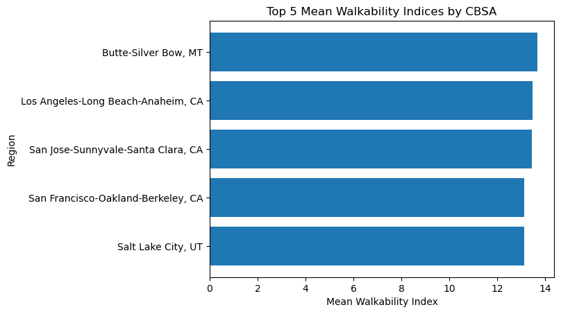

```python
# create a horizontal barchart of the these top 5 CBSAs
plt.barh(top_walkability.index[::-1], top_walkability["NatWalkInd"][::-1])

# label accordingly
plt.xlabel("Mean Walkability Index")
plt.ylabel("Region")
plt.title("Top 5 Mean Walkability Indices by CBSA")
plt.show()
```

Above we see the most walkable CBSA's (metro areas) in the country. These findings largely make sense since 4 of them are major metro areas that have extremely densely populated regions where we would expect to see lots of intersection traffic/density, close proximity to transit stops, and a marge mix of retail, office, and industrial buildings with apartments intermingled.

The fact that Butte-Silver Bow, MT ranks first is certainly surprising, as this is not a well-known and large metro region. It could be possible that the Butte-Silver Bow area has an unusually high and even diversity of building purposes like retail, office, and industrial, with a ton of residential spaces spaced throughout the region evenly. The Butte area is known for [rich deposits of copper and gold](https://www.co.silverbow.mt.us/), so it is possible that the influx of industrial buildings in the area bump up its scores for these employment mix ratings. Even so, this is an interesting finding.

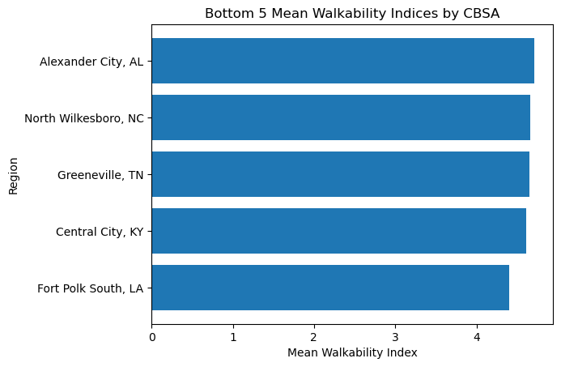

```python
# repeat the procedure for the least walkable CBSAs
worst_walkability = CBSA_averages.sort_values(by=["NatWalkInd"]).head(5)
plt.barh(worst_walkability.index, worst_walkability["NatWalkInd"])
plt.xlabel("Mean Walkability Index")
plt.ylabel("Region")
plt.title("Bottom 5 Mean Walkability Indices by CBSA")
plt.show()
```

Above we can see that most of the least walkable metro areas are in states known to be relatively rural and sparsely populated. Therefore, these findings make sense since relatively less populated metro areas stand to have less dense intersections, less retail and commercial office spaces, and less transit stops.

```python
# create a mapping of state FIPS codes for aggregating data to the state level
state_map = {1 :'AL',
       2 :'AK',
       4 :'AZ',
       5 :'AR',
       6 :'CA',
       8 :'CO',
       9 :'CT',
       10 :'DE',
       11 :'DC',
       12 :'FL',
       13 :'GA',
       15 :'HI',
       16 :'ID',
       17 :'IL',
       18 :'IN',
       19 :'IA',
       20 :'KS',
       21 :'KY',
       22 :'LA',
       23 :'ME',
       24 :'MD',
       25 :'MA',
       26 :'MI',
       27 :'MN',
       28 :'MS',
       29 :'MO',
       30 :'MT',
       31 :'NE',
       32 :'NV',
       33 :'NH',
       34 :'NJ',
       35 :'NM',
       36 :'NY',
       37 :'NC',
       38 :'ND',
       39 :'OH',
       40 :'OK',
       41 :'OR',
       42 :'PA',
       44 :'RI',
       45 :'SC',
       46 :'SD',
       47 :'TN',
       48 :'TX',
       49 :'UT',
       50 :'VT',
       51 :'VA',
       53 :'WA',
       54 :'WV',
       55 :'WI',
       56 :'WY'}
```

A Federal Information Processing Standard (FIPS) code is a standarized way to indentify geographic areas, such as states, by number.

```python
# drop the CBSA name column to enable data aggregation across numeric columns
eda_data.drop(columns=["CBSA_Name"], inplace=True)

# group observations by the state of the block group surveyed
walkable_states = eda_data.groupby(["STATEFP"]).mean()

# function for finding the top and bottom states by mean walkability index and plotting the data
def show_states(top_states):
    # sort by walkability index and get the top or bottom ten based on the parameter
    walkable_states_sorted = walkable_states.sort_values(by=["NatWalkInd"], ascending=(not top_states))[:10]

    # use the mapping to get the names associated with the state FIPS code
    walkable_state_names = [state_map[int(key)] for key in walkable_states_sorted.index]

    # create a bar graph for the states
    plt.bar(walkable_state_names, walkable_states_sorted["NatWalkInd"])
    plt.xlabel("State")
    plt.ylabel("Mean Walkability Index")
    plt.title(f'{"Top" if top_states else "Bottom"} 10 States for Mean Walkability Index of All Regions Surveyed')
    plt.show()
```

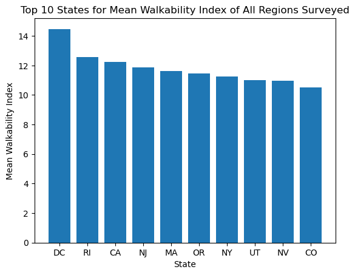

```python
show_states(True)
```

Above we see that the most walkable "state" according to the walkability index measure, is District of Columbia, which is not technically a state but nonetheless treated as one in the data. This is very intuitive since DC is such a small territory and almost all of it is highly urban. Therefore, while other states such as NY have areas that are extremely urban, this is counteracted by all of the more subruban or rural areas of the state, whereas DC is entirely urban. So, it makes sense that on average, the block groupings in DC get extremely high walkability scores.

Rhode Island is a sensible second place state since it too is very small and has some major metro areas. The same goes for New Jersey and Massachusetts.

California, although containing lots of more rural areas, has a huge amount of large metro areas, making it on average quite walkable.

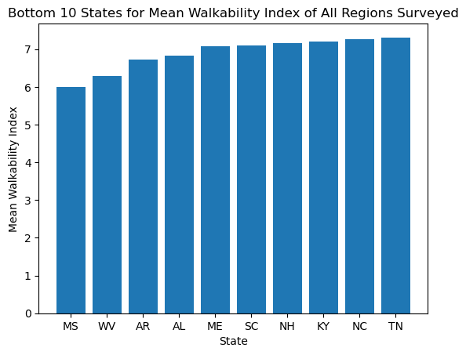

```python
show_states(False)
```

```python
# take random sampling of 50 observations to make scatter plots more visible
rand_sample = cut_data.sample(50, random_state=1)

# function for creating scatter plots with the sampling
def create_scatter(column1, column2):
    plt.scatter(rand_sample[column1], rand_sample[column2])

    # use numpy function to get line of best fit for the data
    slope, intercept = np.polyfit(rand_sample[column1], rand_sample[column2], 1)

    # plot the line using slope intercept form equation
    plt.plot(rand_sample[column1], slope * rand_sample[column1] + intercept)

    plt.xlabel(column1)
    plt.ylabel("Walkability Index")
    plt.title(f'Walkability Index Versus {column1} with Slope {slope.round(3)} and Intercept {intercept.round(3)}')
    plt.show()
```

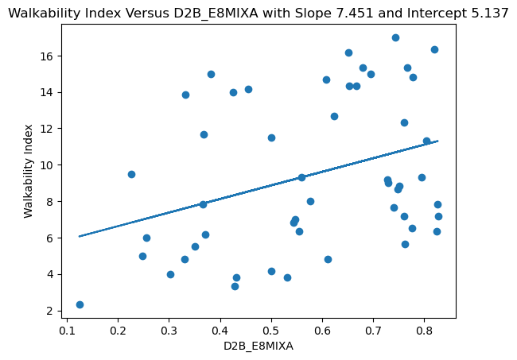

```python
create_scatter("D2B_E8MIXA", "NatWalkInd")
```

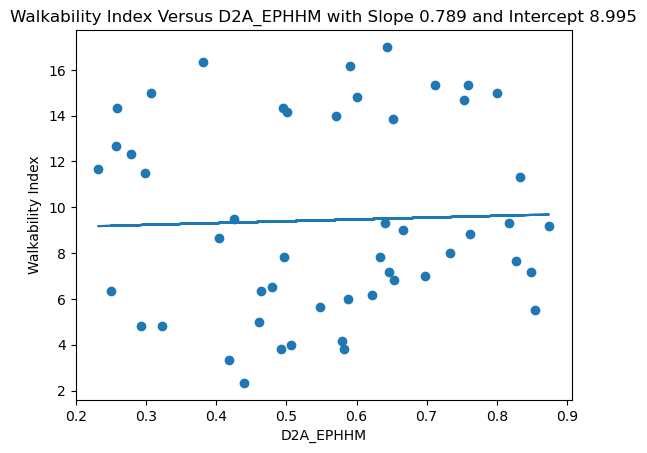

```python
create_scatter("D2A_EPHHM", "NatWalkInd")
```

Here we plot a scatter plot and line of best fit for how employment types and occupied housing combined correlates with the walkability index. We see the slope is much lower than the variable only considering employment mix. This may suggest that employment mix itself is more important than if the employment areas are intermixed with a lot occupied housing.

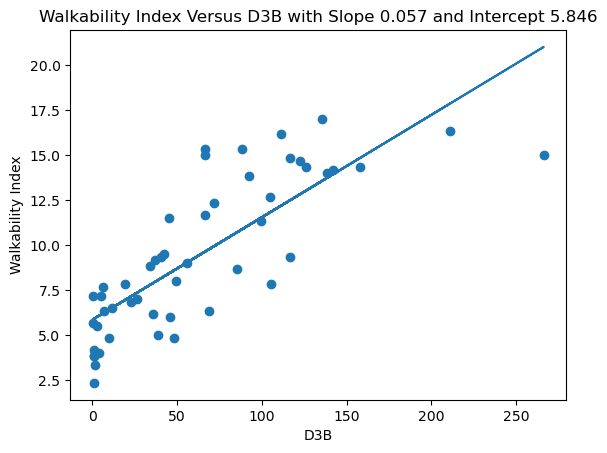

```python
create_scatter("D3B", "NatWalkInd")
```

Here we plot a scatter plot and line of best fit comparing walkability index to intesection density. The scale is far different than the previous two plots, so the slope itself cannot be accurately comnpared. However, we can still comment on how the positive correlation makes sense here as more dense intersections signify more people moving around a given block group, which naturally suggests more walkers in the area.

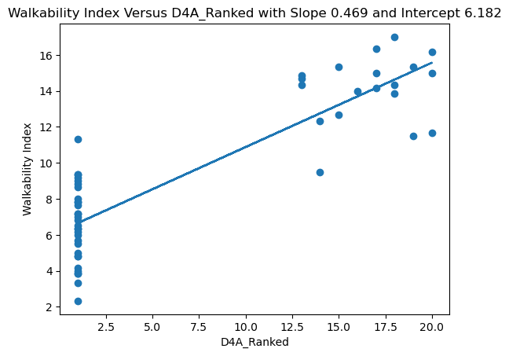

```python
create_scatter("D4A_Ranked", "NatWalkInd")
```

To plot the comparison between walkability index and proximity to transit stops, we use the ranked version of the D4A variable because some values of the raw D4A variable are slighly positive while most are very negative, which made for an inaccurate plot. The ranked variable essentially takes all raw data points and gives them a rank 1-20 based on which of 20 quantiles they fall into when compared to the magnitude of all other data points. And so we can better visualize the data using this ranked version of the variable, and we see a positive correlation, which makes sense since with closer transit stops one would expect that more people would be walking in the immediate area to reach those transit stops.

### Model Analysis and Machine Learning

To assist with analyzing the walkability index score of the CBGs we will be creating some models that will predict the scores based on the four features D2A, D2B, D3B, and D4A. These models will help us learn how important each feature is and how we can predict walkability scores in the future when these features change.

```python
def Mean_Squared_Error(predictions, actual):
    sum_sq_err = 0

    for i in range(0, len(predictions)):
        sq_err = (predictions[i]-actual[i])**2
        sum_sq_err += sq_err

    MSE = sum_sq_err/len(predictions)
    return MSE
```

This is a helper function to calculate the Mean Squared Error for each of our models.

```python
#Ordinary Least Squares Linear Regression
def lin_reg(x_train, y_train, x_test, y_test):
    linreg = LinearRegression().fit(x_train, y_train)

    print('Intercept: ' + str(linreg.intercept_))
    print('D2A Coefficient: ' + str(linreg.coef_[0]))
    print('D2B Coefficient: ' + str(linreg.coef_[1]))
    print('D3B Coefficient: ' + str(linreg.coef_[2]))
    print('D4A Coefficient: ' + str(linreg.coef_[3]))

    predictions = linreg.predict(x_test)
    actual = y_test.to_list()

    MSE = Mean_Squared_Error(predictions, actual)
    print("Mean Squared Error: " + str(MSE))

    return MSE
```

For ordinary least squares linear regression we used the [scikit-learn library](https://scikit-learn.org/stable/modules/generated/sklearn.linear_model.LinearRegression.html) to create a model that was fit with our training data and returns the intercept and 4 weights for the features. The model chooses weights such that the sum of the square errors is minimized.

```python
x = cut_data[['D2A_Ranked', 'D2B_Ranked', 'D3B_Ranked', 'D4A_Ranked']]
y = cut_data['NatWalkInd']
x_train,x_test,y_train,y_test = train_test_split(x,y)

Lin_MSE = lin_reg(x_train, y_train, x_test, y_test)
```

```
Intercept: -1.1228351581848983e-11
D2A Coefficient: 0.1666666666666401
D2B Coefficient: 0.16666666666762908
D3B Coefficient: 0.33333333333451814
D4A Coefficient: 0.33333333333328286
Mean Squared Error: 3.669208881120794e-18
```

```python
# Gradient Descent (Lecture Code)
def grad_descent(x,y,epochs,alpha, x_test, y_test):
    m, n = x.shape
    theta = np.zeros(n)
    loss = np.zeros(epochs)

    for i in range(epochs):
        loss[i] = 0.5*np.linalg.norm(x.dot(theta)-y)**2
        gradient = np.transpose(x).dot(x.dot(theta)-y)
        theta = theta - alpha*gradient

    print('Intercept: ' + str(theta[0]))
    print('D2A Coefficient: ' + str(theta[1]))
    print('D2B Coefficient: ' + str(theta[2]))
    print('D3B Coefficient: ' + str(theta[3]))
    print('D4A Coefficient: ' + str(theta[4]))

    predictions = []
    actual = y_test.to_list()

    for index, row in x_test.iterrows():
        pred = theta[0] + theta[1]*x_test.at[index, 'D2A_Ranked'] + theta[2]*x_test.at[index, 'D2B_Ranked'] + theta[3]*x_test.at[index, 'D3B_Ranked'] + theta[4]*x_test.at[index, 'D4A_Ranked']
        predictions.append(pred)

    MSE = Mean_Squared_Error(predictions, actual)

    print("Mean Squared Error: " + str(MSE))

    return MSE, loss
```

```
Intercept: 0.020065690032665447
D2A Coefficient: 0.21226637271479223
D2B Coefficient: 0.21347179748294529
D3B Coefficient: 0.27859657159232537
D4A Coefficient: 0.25951056421959445
Mean Squared Error: 0.8749099984944253
```

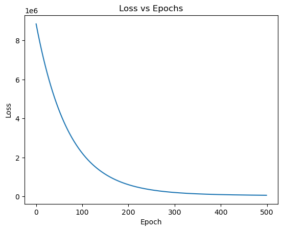

```python
const_col = np.ones([(len(y_train)), 1])
x = np.concatenate((const_col, x_train), 1)
epochs = 500
learning_rate = 0.0000000001
Grad_MSE, loss = grad_descent(x, y_train, epochs, learning_rate, x_test, y_test)

plt.plot(range(epochs), loss)
plt.xlabel('Epoch')
plt.ylabel('Loss')
plt.title('Loss vs Epochs')
```

```python
def k_nearest_neighbors(k, x_train, y_train, x_test, y_test):

    knn = KNeighborsRegressor(n_neighbors = k)
    knn.fit(x_train, y_train)

    predictions = knn.predict(x_test)
    actual = y_test.to_list()

    print("Number of Neighbors: " + str(k))
    MSE = Mean_Squared_Error(predictions, actual)
    print("Mean Squared Error: " + str(MSE))
    score = knn.score(x_test,y_test)
    print("Accuracy: " + str(score))

    return MSE
```

The function implements a [K Nearest Neighbors algorithm](https://scikit-learn.org/stable/modules/generated/sklearn.neighbors.KNeighborsRegressor.html) for regression this is done by finding the k observations with D2A, D2B, D3B, and D4A Ranks that are the closest to that of the test data then taking the average of the National Walkability Index Scores of these k observations and using that as the predicted value.

```python
x = cut_data[['D2A_Ranked', 'D2B_Ranked', 'D3B_Ranked', 'D4A_Ranked']]
y = cut_data['NatWalkInd']
x_train,x_test,y_train,y_test = train_test_split(x,y)

k = math.ceil(math.sqrt(len(x_train)))
Knn_MSE = k_nearest_neighbors(k, x_train, y_train, x_test, y_test)
```

```
Number of Neighbors: 389
Mean Squared Error: 0.023378913818529436
Accuracy: 0.998734320535546
```

It is crucial that the value of K is chosen carefully since a K value that is too small may end up overfitting the data and a K value that is too large may end up underfitting the data. Typically we would use Cross Validation, such as [GridSearch Cross Validation](https://towardsdatascience.com/cross-validation-and-grid-search-efa64b127c1b), to decide on the best value of K within a range of possible values. Due to the large size of our dataset and our computational limits we elected to use a simpler approach by taking the square root of the number of observations in our training data to get our value for K.

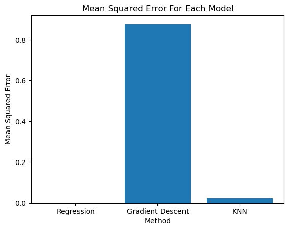

```python
labels = ['Regression', 'Gradient Descent', 'KNN']
values = [Lin_MSE, Grad_MSE, Knn_MSE]

plt.bar(labels, values)
plt.xlabel('Method')
plt.ylabel('Mean Squared Error')
plt.title('Mean Squared Error For Each Model')
```

Above we can see the Mean Squared Errors for our Ordinary Least Squares Regression, Gradient Descent, and K Nearest Neighbors functions. While all three of the models have low error, the Ordinary Least Squares Regression model has a near zero MSE and is useful for determining the current walkability score of a CBG and predicting the walkability score based on changes in the CBG.

### Conclusions and Future Steps

Based on our analysis we can conclude from the weights calculated using the Ordinary Least Squares Regression model that city and community planners should focus on improving the intersection density (D3B) and proximity to transit stops (D4A) in their communities since those features have the higher weights.

In the future we hope that updated Smart Location Database information is released and using that information we can pursue some other lines of thought such as,

1. To keep the Walkability Index simple and understandable the EPA used 4 variables to calculate it, however an investigation into if there more variables that could be used to further improve the accuracy of the walkability index (such as the number of sidewalks blocked due to construction) could prove to be insightful.
2. When creating models to predict the walkability index score of a CBG we considered doing a modification of KNN using the haversine distance from CBG population centroid to centroid, however due to limited computational power we were unable to do this, however the relationship between surrounding CBGs and walkability score could be further explored.

We hope that this tutorial has got you thinking about the walkability of your communities and how you can improve it.